# La Turquie en Comparaison : PIB, Éducation et Inégalités face aux Voisins et à l’Europe (1990-2020)

Omer GIZBILI & Kaan Mert SEVINC

2026-04-28

```r
# Chargement des bibliothèques
library(tidyverse)  # manipulation des données et visualisation
library(knitr)      # génération du rapport
library(kableExtra) # tableaux formatés
library(scales)     # formatage des axes
library(zoo)        # interpolation linéaire pour les valeurs manquantes
```

# 1 Introduction

## 1.1 Contexte

Ce projet analyse le développement économique et social de la Turquie entre 1990 et 2020, en la comparant à ses voisins directs et à cinq grandes économies européennes. Nous nous concentrons sur trois indicateurs clés : le PIB par habitant, les années moyennes de scolarisation et le coefficient de Gini (inégalités de revenus).

**Question de recherche :** *Comment le développement économique et les indicateurs sociaux de la Turquie se comparent-ils à ceux de ses voisins et des grandes économies européennes entre 1990 et 2020 ?*

## 1.2 Sources de Données

Nous utilisons trois jeux de données issus de **Our World in Data**, tous provenant d’institutions internationales reconnues :

[output not shown]

## 1.3 Description des Variables

- **PIB par habitant** : Production économique moyenne par personne, ajustée pour l’inflation et la parité de pouvoir d’achat (PPA). Exprimé en dollars internationaux constants 2021.
- **Années moyennes de scolarisation** : Nombre moyen d’années d’éducation reçues par les personnes âgées de 25 ans et plus.
- **Coefficient de Gini** : Mesure les inégalités de revenus sur une échelle de 0 (égalité parfaite) à 1 (inégalité maximale).

# 2 Méthodologie

## 2.1 Chargement des Données

```r
# Chargement des trois fichiers CSV bruts
# Les chemins sont relatifs au dossier rapport/
gdp_raw  <- read_csv("../data/raw/gdp-per-capita-worldbank.csv")
edu_raw  <- read_csv("../data/raw/mean-years-of-schooling-long-run.csv")
gini_raw <- read_csv("../data/raw/economic-inequality-gini-index.csv")
```

## 2.2 Caractérisation des Données

```r
# Vue d'ensemble de chaque jeu de données : dimensions, pays, période
datasets <- list(
  "PIB par habitant"          = gdp_raw,
  "Années de scolarisation"   = edu_raw,
  "Coefficient de Gini"       = gini_raw
)

carac <- map_dfr(datasets, function(df) {
  tibble(
    Lignes  = nrow(df),
    Colonnes = ncol(df),
    Pays    = n_distinct(df$Entity),
    An_min  = min(df$Year, na.rm = TRUE),
    An_max  = max(df$Year, na.rm = TRUE)
  )
}, .id = "Jeu de données")

kable(carac, caption = "Caractérisation des trois jeux de données") %>%
  kable_styling(bootstrap_options = c("striped", "hover"))
```

Caractérisation des trois jeux de données

| Jeu de données | Lignes | Colonnes | Pays | An_min | An_max |
| --- | --- | --- | --- | --- | --- |
| PIB par habitant | 7240 | 5 | 212 | 1990 | 2024 |
| Années de scolarisation | 3699 | 4 | 153 | 1870 | 2020 |
| Coefficient de Gini | 2389 | 5 | 183 | 1963 | 2025 |

## 2.3 Évaluation de la Qualité des Données

```r
# Valeurs manquantes par jeu de données
missing_report <- map_dfr(datasets, function(df) {
  df %>%
    summarise(across(everything(), ~ sum(is.na(.)))) %>%
    pivot_longer(everything(),
                 names_to  = "Variable",
                 values_to = "Valeurs_manquantes")
}, .id = "Jeu de données")

kable(missing_report, caption = "Valeurs manquantes par variable") %>%
  kable_styling(bootstrap_options = c("striped", "hover"))
```

Valeurs manquantes par variable

| Jeu de données | Variable | Valeurs_manquantes |
| --- | --- | --- |
| PIB par habitant | Entity | 0 |
| PIB par habitant | Code | 0 |
| PIB par habitant | Year | 0 |
| PIB par habitant | GDP per capita | 0 |
| PIB par habitant | World region according to OWID | 455 |
| Années de scolarisation | Entity | 0 |
| Années de scolarisation | Code | 0 |
| Années de scolarisation | Year | 0 |
| Années de scolarisation | Average years of schooling | 0 |
| Coefficient de Gini | Entity | 0 |
| Coefficient de Gini | Code | 109 |
| Coefficient de Gini | Year | 0 |
| Coefficient de Gini | Gini coefficient | 0 |
| Coefficient de Gini | World region according to OWID | 109 |

## 2.4 Nettoyage et Intégration des Données

### 2.4.1 Étape 1 — Construction du dataset complet (left_join)

```r
# Jointure des trois datasets sur Entity et Year
# left_join conserve toutes les lignes du GDP et ajoute schooling/gini quand disponible
# Cela préserve toutes les combinaisons pays-année du dataset GDP
complete_data <- gdp_raw %>%
  rename(gdp = `GDP per capita`) %>%
  select(Entity, Year, gdp) %>%
  left_join(
    edu_raw %>%
      rename(schooling = `Average years of schooling`) %>%
      select(Entity, Year, schooling),
    by = c("Entity", "Year")
  ) %>%
  left_join(
    gini_raw %>%
      rename(gini = `Gini coefficient`) %>%
      select(Entity, Year, gini),
    by = c("Entity", "Year")
  )

cat("Dimensions du dataset complet :", nrow(complete_data), "lignes x", ncol(complete_data), "colonnes\n")
```

```
## Dimensions du dataset complet : 7240 lignes x 5 colonnes
```

```r
cat("Pays :", n_distinct(complete_data$Entity), "\n")
```

```
## Pays : 212
```

```r
cat("Années :", min(complete_data$Year), "à", max(complete_data$Year), "\n")
```

```
## Années : 1990 à 2024
```

### 2.4.2 Étape 2 — Définition de la liste des pays

```r
# Turquie + 8 voisins + 5 grandes économies européennes
countries <- c(
  "Turkey",
  # Voisins
  "Greece", "Bulgaria", "Georgia", "Armenia", "Azerbaijan",
  "Iran", "Iraq", "Syria",
  # Grandes économies européennes
  "Spain", "United Kingdom", "France", "Germany", "Italy"
)

cat("Nombre total de pays sélectionnés :", length(countries), "\n")
```

```
## Nombre total de pays sélectionnés : 14
```

### 2.4.3 Étape 3 — Filtrage du dataset d’analyse

```r
# Conservation uniquement des pays sélectionnés et des années 1990-2020
analysis_data <- complete_data %>%
  filter(Entity %in% countries,
         Year >= 1990, Year <= 2020)

cat("Dataset d'analyse :", nrow(analysis_data), "lignes\n")
```

```
## Dataset d'analyse : 434 lignes
```

### 2.4.4 Étape 4 — Couverture des données par pays

```r
# Combien d'observations non manquantes par pays et par variable ?
coverage <- analysis_data %>%
  group_by(Entity) %>%
  summarise(
    n_gdp       = sum(!is.na(gdp)),
    n_schooling = sum(!is.na(schooling)),
    n_gini      = sum(!is.na(gini))
  ) %>%
  arrange(desc(n_gdp))

kable(coverage,
      caption = "Couverture des données par pays (1990-2020)",
      col.names = c("Pays", "Obs. PIB", "Obs. Scolarisation", "Obs. Gini")) %>%
  kable_styling(bootstrap_options = c("striped", "hover"))
```

Couverture des données par pays (1990-2020)

| Pays | Obs. PIB | Obs. Scolarisation | Obs. Gini |
| --- | --- | --- | --- |
| Armenia | 31 | 2 | 21 |
| Azerbaijan | 31 | 0 | 6 |
| Bulgaria | 31 | 7 | 16 |
| France | 31 | 7 | 26 |
| Georgia | 31 | 0 | 25 |
| Germany | 31 | 7 | 30 |
| Greece | 31 | 7 | 21 |
| Iran | 31 | 7 | 16 |
| Iraq | 31 | 7 | 2 |
| Italy | 31 | 7 | 24 |
| Spain | 31 | 7 | 27 |
| Syria | 31 | 7 | 4 |
| Turkey | 31 | 7 | 20 |
| United Kingdom | 31 | 7 | 31 |

**Observations :**

- Les données GDP sont complètes pour les 14 pays (31 observations chacun).
- Les données de scolarisation sont disponibles environ tous les 5 ans ; l’Azerbaïdjan et la Géorgie n’ont aucune donnée.
- Les données Gini sont très incomplètes pour l’Irak (2 obs.), la Syrie (4 obs.) et l’Azerbaïdjan (6 obs.).

# 3 Analyse

## 3.1 PIB par Habitant

### 3.1.1 Tous les pays

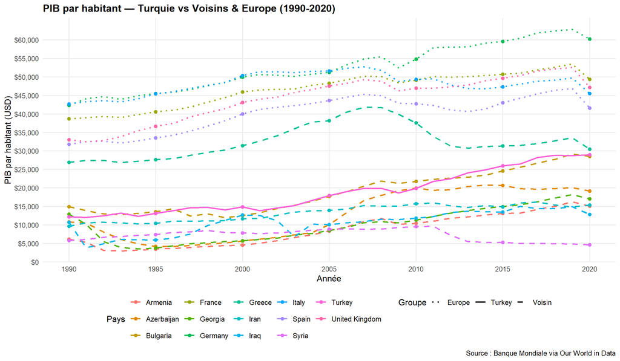

```r
# Les 14 pays, le type de ligne distingue les groupes
# La Turquie est mise en valeur avec une ligne continue
analysis_data %>%
  mutate(group = ifelse(Entity == "Turkey", "Turkey",
                 ifelse(Entity %in% c("Greece", "Bulgaria", "Georgia",
                                       "Armenia", "Azerbaijan", "Iran",
                                       "Iraq", "Syria"),
                        "Voisin", "Europe"))) %>%
  ggplot(aes(x = Year, y = gdp, color = Entity, linetype = group)) +
  geom_line(linewidth = 1) +
  geom_point(data = . %>% filter(Year %in% c(1990, 1995, 2000, 2005, 2010, 2015, 2020)),
             size = 2) +
  scale_y_continuous(labels = label_dollar(big.mark = ","),
                     breaks = seq(0, 60000, by = 5000)) +
  scale_x_continuous(breaks = seq(1990, 2020, by = 5)) +
  scale_linetype_manual(values = c("Turkey" = "solid",
                                   "Voisin" = "dashed",
                                   "Europe" = "dotted")) +
  labs(title   = "PIB par habitant — Turquie vs Voisins & Europe (1990-2020)",
       x       = "Année", y = "PIB par habitant (USD)",
       color   = "Pays", linetype = "Groupe",
       caption = "Source : Banque Mondiale via Our World in Data") +
  theme_minimal(base_size = 12) +
  theme(plot.title       = element_text(face = "bold"),
        legend.position  = "bottom",
        panel.grid.minor = element_blank())
```

### 3.1.2 Turquie vs Voisins

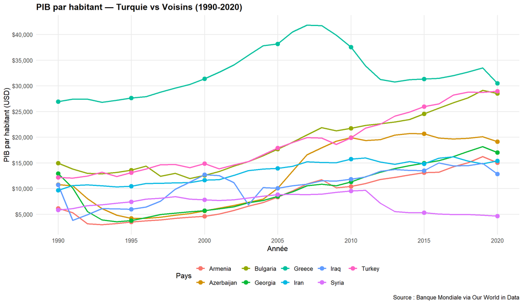

```r
analysis_data %>%
  filter(Entity %in% c("Turkey", "Greece", "Bulgaria", "Georgia",
                        "Armenia", "Azerbaijan", "Iran", "Iraq", "Syria")) %>%
  ggplot(aes(x = Year, y = gdp, color = Entity)) +
  geom_line(linewidth = 1) +
  geom_point(data = . %>% filter(Year %in% c(1990, 1995, 2000, 2005, 2010, 2015, 2020)),
             size = 3) +
  scale_y_continuous(labels = label_dollar(big.mark = ","),
                     breaks = seq(0, 40000, by = 5000)) +
  scale_x_continuous(breaks = seq(1990, 2020, by = 5)) +
  labs(title   = "PIB par habitant — Turquie vs Voisins (1990-2020)",
       x       = "Année", y = "PIB par habitant (USD)", color = "Pays",
       caption = "Source : Banque Mondiale via Our World in Data") +
  theme_minimal(base_size = 12) +
  theme(plot.title       = element_text(face = "bold"),
        legend.position  = "bottom",
        panel.grid.minor = element_blank())
```

### 3.1.3 Turquie vs Europe

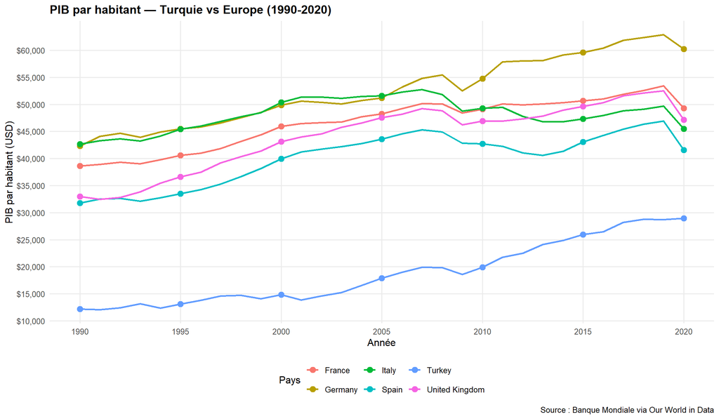

```r
analysis_data %>%
  filter(Entity %in% c("Turkey", "Spain", "United Kingdom",
                        "France", "Germany", "Italy")) %>%
  ggplot(aes(x = Year, y = gdp, color = Entity)) +
  geom_line(linewidth = 1) +
  geom_point(data = . %>% filter(Year %in% c(1990, 1995, 2000, 2005, 2010, 2015, 2020)),
             size = 3) +
  scale_y_continuous(labels = label_dollar(big.mark = ","),
                     breaks = seq(0, 60000, by = 5000)) +
  scale_x_continuous(breaks = seq(1990, 2020, by = 5)) +
  labs(title   = "PIB par habitant — Turquie vs Europe (1990-2020)",
       x       = "Année", y = "PIB par habitant (USD)", color = "Pays",
       caption = "Source : Banque Mondiale via Our World in Data") +
  theme_minimal(base_size = 12) +
  theme(plot.title       = element_text(face = "bold"),
        legend.position  = "bottom",
        panel.grid.minor = element_blank())
```

## 3.2 Années Moyennes de Scolarisation

### 3.2.1 Tous les pays

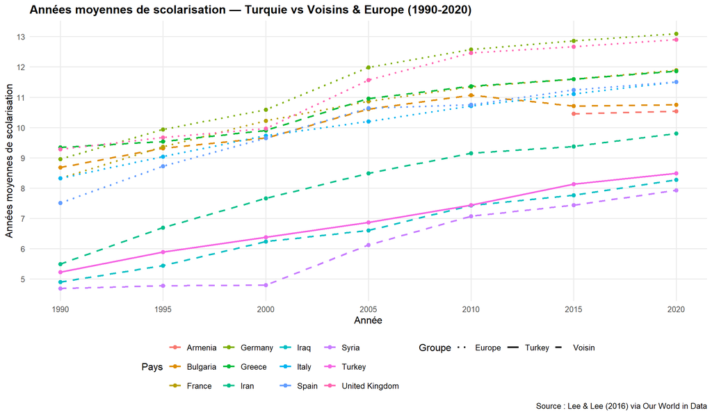

```r
analysis_data %>%
  filter(!is.na(schooling)) %>%
  mutate(group = ifelse(Entity == "Turkey", "Turkey",
                 ifelse(Entity %in% c("Greece", "Bulgaria", "Georgia",
                                       "Armenia", "Azerbaijan", "Iran",
                                       "Iraq", "Syria"),
                        "Voisin", "Europe"))) %>%
  ggplot(aes(x = Year, y = schooling, color = Entity, linetype = group)) +
  geom_line(linewidth = 1) +
  geom_point(size = 2) +
  scale_y_continuous(breaks = seq(0, 15, by = 1)) +
  scale_x_continuous(breaks = seq(1990, 2020, by = 5)) +
  scale_linetype_manual(values = c("Turkey" = "solid",
                                   "Voisin" = "dashed",
                                   "Europe" = "dotted")) +
  labs(title   = "Années moyennes de scolarisation — Turquie vs Voisins & Europe (1990-2020)",
       x       = "Année", y = "Années moyennes de scolarisation",
       color   = "Pays", linetype = "Groupe",
       caption = "Source : Lee & Lee (2016) via Our World in Data") +
  theme_minimal(base_size = 12) +
  theme(plot.title       = element_text(face = "bold"),
        legend.position  = "bottom",
        panel.grid.minor = element_blank())
```

### 3.2.2 Turquie vs Voisins

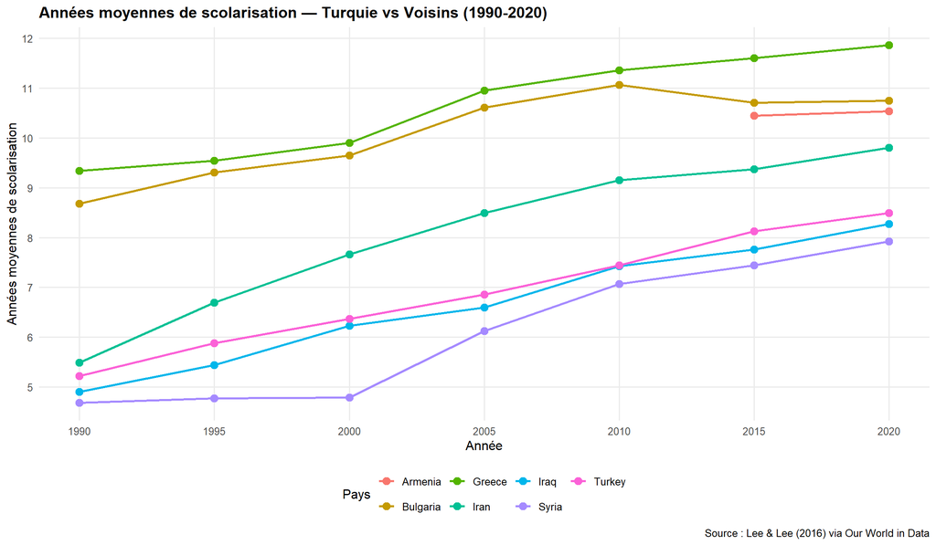

```r
analysis_data %>%
  filter(Entity %in% c("Turkey", "Greece", "Bulgaria", "Georgia",
                        "Armenia", "Azerbaijan", "Iran", "Iraq", "Syria"),
         !is.na(schooling)) %>%
  ggplot(aes(x = Year, y = schooling, color = Entity)) +
  geom_line(linewidth = 1) +
  geom_point(size = 3) +
  scale_y_continuous(breaks = seq(0, 15, by = 1)) +
  scale_x_continuous(breaks = seq(1990, 2020, by = 5)) +
  labs(title   = "Années moyennes de scolarisation — Turquie vs Voisins (1990-2020)",
       x       = "Année", y = "Années moyennes de scolarisation", color = "Pays",
       caption = "Source : Lee & Lee (2016) via Our World in Data") +
  theme_minimal(base_size = 12) +
  theme(plot.title       = element_text(face = "bold"),
        legend.position  = "bottom",
        panel.grid.minor = element_blank())
```

### 3.2.3 Turquie vs Europe

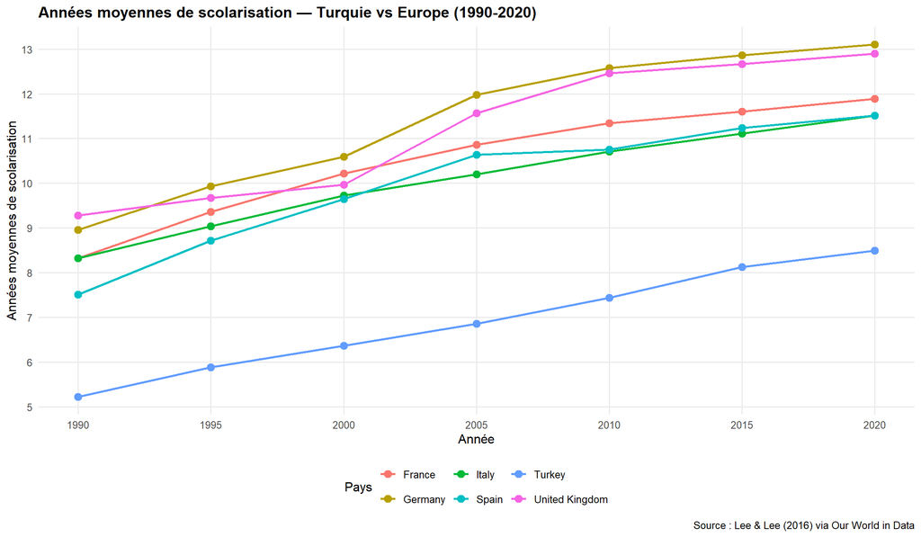

```r
analysis_data %>%
  filter(Entity %in% c("Turkey", "Spain", "United Kingdom",
                        "France", "Germany", "Italy"),
         !is.na(schooling)) %>%
  ggplot(aes(x = Year, y = schooling, color = Entity)) +
  geom_line(linewidth = 1) +
  geom_point(size = 3) +
  scale_y_continuous(breaks = seq(0, 15, by = 1)) +
  scale_x_continuous(breaks = seq(1990, 2020, by = 5)) +
  labs(title   = "Années moyennes de scolarisation — Turquie vs Europe (1990-2020)",
       x       = "Année", y = "Années moyennes de scolarisation", color = "Pays",
       caption = "Source : Lee & Lee (2016) via Our World in Data") +
  theme_minimal(base_size = 12) +
  theme(plot.title       = element_text(face = "bold"),
        legend.position  = "bottom",
        panel.grid.minor = element_blank())
```

## 3.3 Coefficient de Gini

Les valeurs manquantes sont interpolées linéairement avec `zoo::na.approx()` pour permettre un tracé continu. Les valeurs manquantes originales sont préservées dans `analysis_data`.

### 3.3.1 Tous les pays

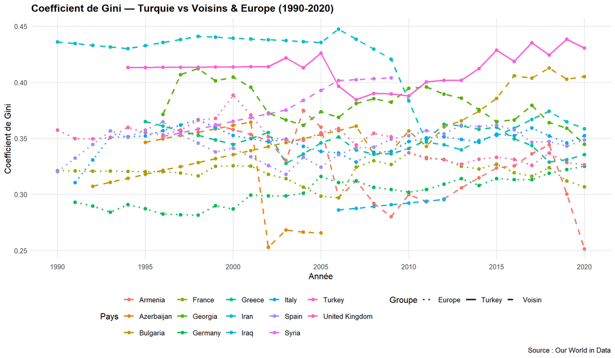

```r
analysis_data %>%
  mutate(group = ifelse(Entity == "Turkey", "Turkey",
                 ifelse(Entity %in% c("Greece", "Bulgaria", "Georgia",
                                       "Armenia", "Azerbaijan", "Iran",
                                       "Iraq", "Syria"),
                        "Voisin", "Europe"))) %>%
  group_by(Entity) %>%
  mutate(gini = zoo::na.approx(gini, na.rm = FALSE)) %>%
  ungroup() %>%
  ggplot(aes(x = Year, y = gini, color = Entity, linetype = group)) +
  geom_line(linewidth = 1, na.rm = TRUE) +
  geom_point(data = . %>% filter(!is.na(gini)), size = 2) +
  scale_y_continuous(breaks = seq(0, 0.6, by = 0.05)) +
  scale_x_continuous(breaks = seq(1990, 2020, by = 5)) +
  scale_linetype_manual(values = c("Turkey" = "solid",
                                   "Voisin" = "dashed",
                                   "Europe" = "dotted")) +
  labs(title   = "Coefficient de Gini — Turquie vs Voisins & Europe (1990-2020)",
       x       = "Année", y = "Coefficient de Gini",
       color   = "Pays", linetype = "Groupe",
       caption = "Source : Our World in Data") +
  theme_minimal(base_size = 12) +
  theme(plot.title       = element_text(face = "bold"),
        legend.position  = "bottom",
        panel.grid.minor = element_blank())
```

### 3.3.2 Turquie vs Voisins

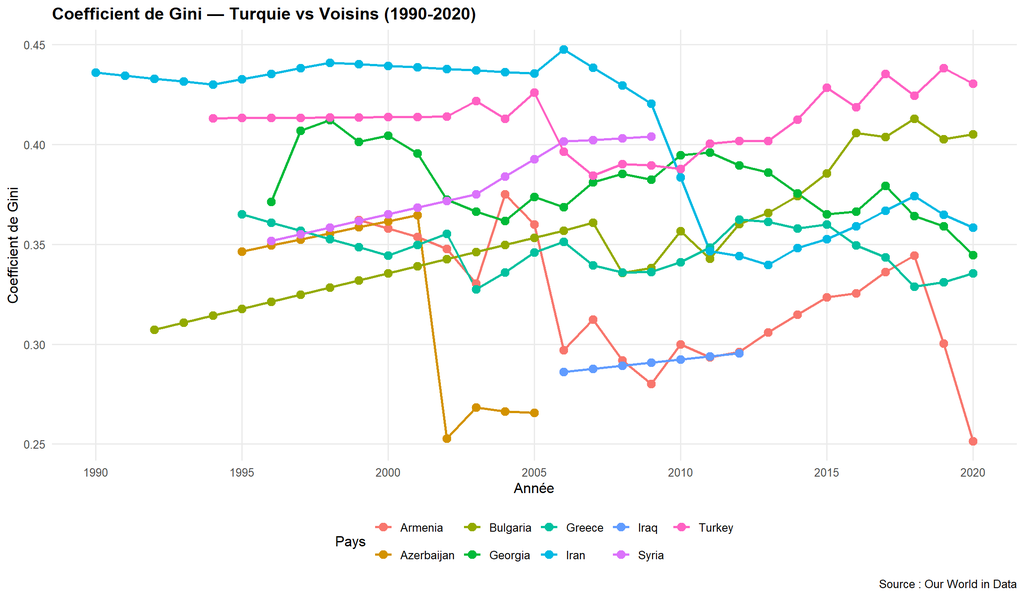

```r
analysis_data %>%
  filter(Entity %in% c("Turkey", "Greece", "Bulgaria", "Georgia",
                        "Armenia", "Azerbaijan", "Iran", "Iraq", "Syria")) %>%
  group_by(Entity) %>%
  mutate(gini = zoo::na.approx(gini, na.rm = FALSE)) %>%
  ungroup() %>%
  ggplot(aes(x = Year, y = gini, color = Entity)) +
  geom_line(linewidth = 1, na.rm = TRUE) +
  geom_point(data = . %>% filter(!is.na(gini)), size = 3) +
  scale_y_continuous(breaks = seq(0, 0.6, by = 0.05)) +
  scale_x_continuous(breaks = seq(1990, 2020, by = 5)) +
  labs(title   = "Coefficient de Gini — Turquie vs Voisins (1990-2020)",
       x       = "Année", y = "Coefficient de Gini", color = "Pays",
       caption = "Source : Our World in Data") +
  theme_minimal(base_size = 12) +
  theme(plot.title       = element_text(face = "bold"),
        legend.position  = "bottom",
        panel.grid.minor = element_blank())
```

### 3.3.3 Turquie vs Europe

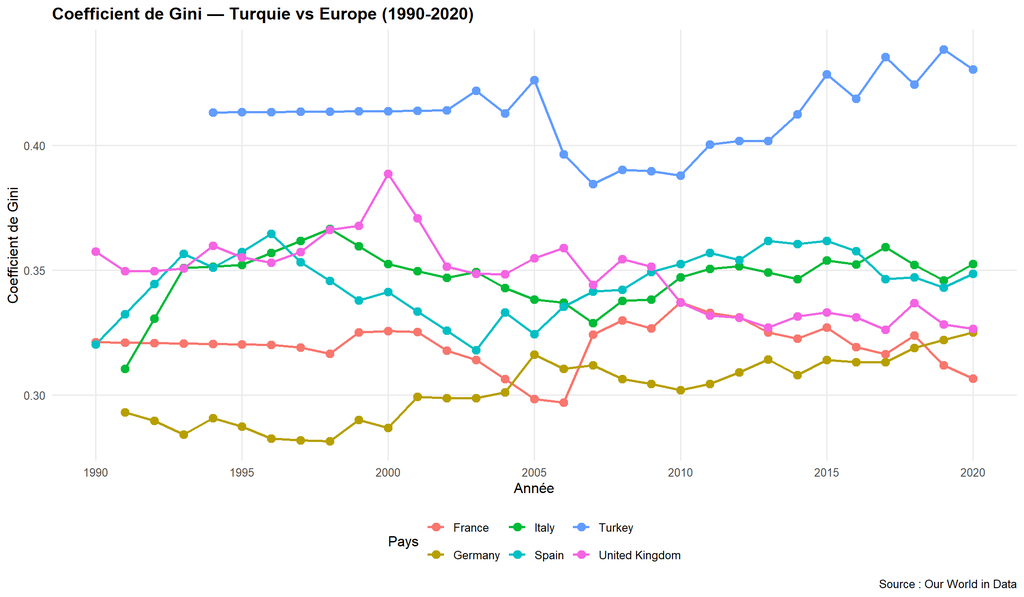

```r
analysis_data %>%
  filter(Entity %in% c("Turkey", "Spain", "United Kingdom",
                        "France", "Germany", "Italy")) %>%
  group_by(Entity) %>%
  mutate(gini = zoo::na.approx(gini, na.rm = FALSE)) %>%
  ungroup() %>%
  ggplot(aes(x = Year, y = gini, color = Entity)) +
  geom_line(linewidth = 1, na.rm = TRUE) +
  geom_point(data = . %>% filter(!is.na(gini)), size = 3) +
  scale_y_continuous(breaks = seq(0, 0.6, by = 0.05)) +
  scale_x_continuous(breaks = seq(1990, 2020, by = 5)) +
  labs(title   = "Coefficient de Gini — Turquie vs Europe (1990-2020)",
       x       = "Année", y = "Coefficient de Gini", color = "Pays",
       caption = "Source : Our World in Data") +
  theme_minimal(base_size = 12) +
  theme(plot.title       = element_text(face = "bold"),
        legend.position  = "bottom",
        panel.grid.minor = element_blank())
```

## 3.4 Analyse de Corrélation

```r
# Corrélations globales sur les 14 pays
cat("=== Corrélations globales ===\n")
```

```
## === Corrélations globales ===
```

```r
cat("PIB ~ Scolarisation :", round(cor(analysis_data$gdp, analysis_data$schooling, use = "complete.obs"), 3), "\n")
```

```
## PIB ~ Scolarisation : 0.777
```

```r
cat("PIB ~ Gini :         ", round(cor(analysis_data$gdp, analysis_data$gini,      use = "complete.obs"), 3), "\n\n")
```

```
## PIB ~ Gini :          -0.398
```

```r
# Corrélations par pays (uniquement pour les pays avec au moins 3 points de données)
cor_table <- analysis_data %>%
  group_by(Entity) %>%
  summarise(
    cor_gdp_schooling = ifelse(sum(!is.na(schooling)) >= 3,
                               round(cor(gdp, schooling, use = "complete.obs"), 3), NA),
    cor_gdp_gini      = ifelse(sum(!is.na(gini)) >= 3,
                               round(cor(gdp, gini, use = "complete.obs"), 3), NA)
  )

kable(cor_table,
      caption = "Corrélations de Pearson par pays",
      col.names = c("Pays", "PIB ~ Scolarisation", "PIB ~ Gini")) %>%
  kable_styling(bootstrap_options = c("striped", "hover")) %>%
  row_spec(which(cor_table$Entity == "Turkey"), bold = TRUE, background = "#fff3f3")
```

Corrélations de Pearson par pays

| Pays | PIB ~ Scolarisation | PIB ~ Gini |
| --- | --- | --- |
| Armenia | NA | -0.557 |
| Azerbaijan | NA | -0.670 |
| Bulgaria | 0.754 | 0.905 |
| France | 0.973 | 0.032 |
| Georgia | NA | -0.544 |
| Germany | 0.963 | 0.880 |
| Greece | 0.557 | -0.480 |
| Iran | 0.967 | -0.706 |
| Iraq | 0.645 | NA |
| Italy | 0.383 | -0.077 |
| Spain | 0.931 | -0.137 |
| Syria | -0.263 | 0.948 |
| Turkey | 0.972 | 0.449 |
| United Kingdom | 0.897 | -0.516 |

**Observations clés :**

- La Turquie présente une corrélation très forte entre PIB et scolarisation (r = 0,972), similaire à la France (0,973), l’Allemagne (0,963) et l’Iran (0,967).
- La corrélation PIB ~ Gini pour la Turquie (0,449) suggère que la croissance économique s’est accompagnée d’une augmentation modérée des inégalités.
- La Syrie présente une corrélation négative PIB ~ Scolarisation (-0,263), probablement due à l’effondrement du PIB pendant la guerre civile tandis que les indicateurs éducatifs restaient relativement stables.

## 3.5 Analyse de Régression

### 3.5.1 Modèle 1 — PIB ~ Scolarisation

```r
# Régression linéaire simple : l'éducation prédit-elle le PIB ?
model_schooling <- lm(gdp ~ schooling, data = analysis_data)
summary(model_schooling)
```

```
##
## Call:
## lm(formula = gdp ~ schooling, data = analysis_data)
##
## Residuals:
##    Min     1Q Median     3Q    Max
## -23176  -7215   2199   7211  18680
##
## Coefficients:
##             Estimate Std. Error t value Pr(>|t|)
## (Intercept) -24112.2     5088.6  -4.738 9.66e-06 ***
## schooling     5779.9      533.3  10.838  < 2e-16 ***
## ---
## Signif. codes:  0 '***' 0.001 '**' 0.01 '*' 0.05 '.' 0.1 ' ' 1
##
## Residual standard error: 10420 on 77 degrees of freedom
##   (355 observations deleted due to missingness)
## Multiple R-squared:  0.604,  Adjusted R-squared:  0.5989
## F-statistic: 117.5 on 1 and 77 DF,  p-value: < 2.2e-16
```

**Interprétation :** Chaque année de scolarisation supplémentaire est associée à une augmentation moyenne de **5 780 USD** du PIB par habitant. Le modèle explique **60,4 %** de la variance du PIB (R² = 0,604). La p-valeur est extrêmement faible (< 2,2e-16), confirmant la significativité statistique.

### 3.5.2 Modèle 2 — PIB ~ Gini

```r
# Régression linéaire simple : les inégalités prédisent-elles le PIB ?
model_gini <- lm(gdp ~ gini, data = analysis_data)
summary(model_gini)
```

```
##
## Call:
## lm(formula = gdp ~ gini, data = analysis_data)
##
## Residuals:
##    Min     1Q Median     3Q    Max
## -42850 -12146   3598  12801  25573
##
## Coefficients:
##             Estimate Std. Error t value Pr(>|t|)
## (Intercept)    94301       8723  10.811  < 2e-16 ***
## gini         -177033      24958  -7.093 1.18e-11 ***
## ---
## Signif. codes:  0 '***' 0.001 '**' 0.01 '*' 0.05 '.' 0.1 ' ' 1
##
## Residual standard error: 15280 on 267 degrees of freedom
##   (165 observations deleted due to missingness)
## Multiple R-squared:  0.1586, Adjusted R-squared:  0.1554
## F-statistic: 50.32 on 1 and 267 DF,  p-value: 1.175e-11
```

**Interprétation :** Le coefficient de Gini seul n’explique que **15,9 %** de la variance du PIB (R² = 0,159). Le coefficient négatif (-177 033) suggère qu’une inégalité plus élevée est associée à un PIB plus faible, mais le pouvoir explicatif du modèle est faible.

### 3.5.3 Modèle 3 — PIB ~ Scolarisation + Gini

```r
# Régression multiple : les deux variables ensemble
model_full <- lm(gdp ~ schooling + gini, data = analysis_data)
summary(model_full)
```

```
##
## Call:
## lm(formula = gdp ~ schooling + gini, data = analysis_data)
##
## Residuals:
##    Min     1Q Median     3Q    Max
## -30212  -3672   3079   5833  15756
##
## Coefficients:
##             Estimate Std. Error t value Pr(>|t|)
## (Intercept)    18140      23428   0.774 0.442571
## schooling       4272       1054   4.054 0.000184 ***
## gini          -71226      44454  -1.602 0.115667
## ---
## Signif. codes:  0 '***' 0.001 '**' 0.01 '*' 0.05 '.' 0.1 ' ' 1
##
## Residual standard error: 10110 on 48 degrees of freedom
##   (383 observations deleted due to missingness)
## Multiple R-squared:  0.4403, Adjusted R-squared:  0.417
## F-statistic: 18.88 on 2 and 48 DF,  p-value: 8.925e-07
```

**Interprétation :** En combinant les deux variables, le R² tombe à **0,440** par rapport au Modèle 1. Cela s’explique par le fait que de nombreuses observations avec des données Gini manquantes sont exclues du modèle, réduisant la taille de l’échantillon de 79 à 51 observations. La scolarisation reste très significative (p < 0,001) tandis que le Gini n’est pas significatif (p = 0,116) une fois la scolarisation contrôlée.

# 4 Conclusion

Cette analyse a comparé le PIB par habitant, le niveau d’éducation et les inégalités de revenus de la Turquie par rapport à ses voisins et à cinq grandes économies européennes sur la période 1990–2020.

**Limites :**

- Les données de scolarisation ne sont disponibles que tous les 5 ans ; une interpolation linéaire a été utilisée pour la visualisation.
- Les données Gini sont très incomplètes pour plusieurs pays (Azerbaïdjan, Irak, Syrie).
- La corrélation et la régression n’impliquent pas de causalité.
- Le PIB par habitant au niveau national masque les disparités régionales internes.

**Perspectives :**

- Intégrer des données régionales (par exemple les régions NUTS pour la Turquie et les pays de l’UE).
- Analyser les écarts de genre dans l’éducation et leur relation avec les inégalités.
- Étendre la période jusqu’en 2024 en utilisant les données GDP disponibles.

# 5 Références

- Eurostat, OCDE, FMI et Banque Mondiale (2026). *PIB par habitant – Banque Mondiale – En dollars internationaux constants*. Our World in Data. https://ourworldindata.org/grapher/gdp-per-capita-worldbank
- Lee, J.-W. et Lee, H. (2016). Human capital in the long run. *Journal of Development Economics*, 122, 147–169.
- R Core Team (2024). *R : un environnement de langage et de calcul statistique*. R Foundation for Statistical Computing, Vienne, Autriche.
- Wickham, H. et al. (2019). Welcome to the tidyverse. *Journal of Open Source Software*, 4(43), 1686.
- Zeileis, A. et Grothendieck, G. (2005). zoo: S3 infrastructure for regular and irregular time series. *Journal of Statistical Software*, 14(6), 1–27.